# cleaning_and_splitting_movie_genres (1)

## In This notebook,

We will extract the unique genres from the movies data set and plot them to see the most popular movie genres of all time

```python
import pandas as pd
pd.set_option('display.max_columns', None)
import numpy as np
import matplotlib.pyplot as plt
import os
```

**Ensure your pandas version is atleaset 0.25**

otherwise you can't use the explode function

```python
print(pd.__version__)
```

```
1.4.3
```

```python
# Read the dataset in from the website if it's not yet here

if not os.path.exists('movies.csv'):
    !curl https://d17h27t6h515a5.cloudfront.net/topher/2017/October/59dd1c4c_tmdb-movies/tmdb-movies.csv -o movies.csv
```

```python
movies = pd.read_csv('movies.csv', sep=',')
movies.head(2)
```

|  | id | imdb_id | popularity | budget | revenue | original_title | cast | homepage | director | tagline | keywords | overview | runtime | genres | production_companies | release_date | vote_count | vote_average | release_year | budget_adj | revenue_adj |
| --- | --- | --- | --- | --- | --- | --- | --- | --- | --- | --- | --- | --- | --- | --- | --- | --- | --- | --- | --- | --- | --- |
| 0 | 135397 | tt0369610 | 32.985763 | 150000000 | 1513528810 | Jurassic World | Chris Pratt\|Bryce Dallas Howard\|Irrfan Khan\|Vi... | http://www.jurassicworld.com/ | Colin Trevorrow | The park is open. | monster\|dna\|tyrannosaurus rex\|velociraptor\|island | Twenty-two years after the events of Jurassic ... | 124 | Action\|Adventure\|Science Fiction\|Thriller | Universal Studios\|Amblin Entertainment\|Legenda... | 6/9/15 | 5562 | 6.5 | 2015 | 1.379999e+08 | 1.392446e+09 |
| 1 | 76341 | tt1392190 | 28.419936 | 150000000 | 378436354 | Mad Max: Fury Road | Tom Hardy\|Charlize Theron\|Hugh Keays-Byrne\|Nic... | http://www.madmaxmovie.com/ | George Miller | What a Lovely Day. | future\|chase\|post-apocalyptic\|dystopia\|australia | An apocalyptic story set in the furthest reach... | 120 | Action\|Adventure\|Science Fiction\|Thriller | Village Roadshow Pictures\|Kennedy Miller Produ... | 5/13/15 | 6185 | 7.1 | 2015 | 1.379999e+08 | 3.481613e+08 |

```python
# let's see the shape
movies.shape
```

```
(10866, 21)
```

```python
# check for missing values in the entire dataset

movies.isna().sum()
```

```
id                         0
imdb_id                   10
popularity                 0
budget                     0
revenue                    0
original_title             0
cast                      76
homepage                7930
director                  44
tagline                 2824
keywords                1493
overview                   4
runtime                    0
genres                    23
production_companies    1030
release_date               0
vote_count                 0
vote_average               0
release_year               0
budget_adj                 0
revenue_adj                0
dtype: int64
```

```python
# Let's see the genres
movies.genres.head()
```

```
0    Action|Adventure|Science Fiction|Thriller
1    Action|Adventure|Science Fiction|Thriller
2           Adventure|Science Fiction|Thriller
3     Action|Adventure|Science Fiction|Fantasy
4                        Action|Crime|Thriller
Name: genres, dtype: object
```

```python
movies.genres.dtype
```

```
dtype('O')
```

We can see that the `genre` column is object type or string. Our goal is to make each genre a unique column in the `movies` dataframe

First, we need to clean each string in the movie `genres` column, remove whitespace and replace any hyphens with underscores and make all genres small case for uniformity.

Before all of that we must treat the missing values, this time I will replace them with a string 'N/A'

```python
movies.genres.isna().sum()
```

```
23
```

```python
movies.genres.fillna('N/A', inplace=True)
```

```python
# Confirming

movies.genres.isna().sum()
```

```
0
```

```python
# Let's see the genres
movies.genres.head()
```

```
0    Action|Adventure|Science Fiction|Thriller
1    Action|Adventure|Science Fiction|Thriller
2           Adventure|Science Fiction|Thriller
3     Action|Adventure|Science Fiction|Fantasy
4                        Action|Crime|Thriller
Name: genres, dtype: object
```

```python
def strip_lower_col(col, df=movies):
    """This function strips whitespaces and
        lowers each letter of values in a col

    @param col: string, a col name in a df
    @param df: a pandas dataframe
    @return: None, cleans in place
    """
    df[col] = df[col].apply(lambda x: x.strip().lower())

    print('Stripped & Lowered!')
```

```python
# now, clean the columns

strip_lower_col('genres')
```

```
Stripped & Lowered!
```

```python
# Now let's replace any whitespaces and hyphens with underscores in genres column

movies.genres.replace([' ', '-'], '_', inplace=True, regex=True)
```

```python
# Let's see the genres
movies.genres.head()
```

```
0    action|adventure|science_fiction|thriller
1    action|adventure|science_fiction|thriller
2           adventure|science_fiction|thriller
3     action|adventure|science_fiction|fantasy
4                        action|crime|thriller
Name: genres, dtype: object
```

Next, we will convert each row to a list of strings. Since each string is divided by a '|', we use that for the separation

```python
movies['genres'] = movies['genres'].apply(lambda x: x.split('|'))
```

```python
# Let's see the genres
movies.genres.head()
```

```
0    [action, adventure, science_fiction, thriller]
1    [action, adventure, science_fiction, thriller]
2            [adventure, science_fiction, thriller]
3     [action, adventure, science_fiction, fantasy]
4                         [action, crime, thriller]
Name: genres, dtype: object
```

```python
movies.shape
```

```
(10866, 21)
```

```python
genres_exploded = movies.explode('genres', ignore_index=True)

# Lets see shape
genres_exploded.shape
```

```
(26983, 21)
```

```python
type(genres_exploded)
```

```
pandas.core.frame.DataFrame
```

```python
genres_exploded.head()
```

|  | id | imdb_id | popularity | budget | revenue | original_title | cast | homepage | director | tagline | keywords | overview | runtime | genres | production_companies | release_date | vote_count | vote_average | release_year | budget_adj | revenue_adj |
| --- | --- | --- | --- | --- | --- | --- | --- | --- | --- | --- | --- | --- | --- | --- | --- | --- | --- | --- | --- | --- | --- |
| 0 | 135397 | tt0369610 | 32.985763 | 150000000 | 1513528810 | Jurassic World | Chris Pratt\|Bryce Dallas Howard\|Irrfan Khan\|Vi... | http://www.jurassicworld.com/ | Colin Trevorrow | The park is open. | monster\|dna\|tyrannosaurus rex\|velociraptor\|island | Twenty-two years after the events of Jurassic ... | 124 | action | Universal Studios\|Amblin Entertainment\|Legenda... | 6/9/15 | 5562 | 6.5 | 2015 | 1.379999e+08 | 1.392446e+09 |
| 1 | 135397 | tt0369610 | 32.985763 | 150000000 | 1513528810 | Jurassic World | Chris Pratt\|Bryce Dallas Howard\|Irrfan Khan\|Vi... | http://www.jurassicworld.com/ | Colin Trevorrow | The park is open. | monster\|dna\|tyrannosaurus rex\|velociraptor\|island | Twenty-two years after the events of Jurassic ... | 124 | adventure | Universal Studios\|Amblin Entertainment\|Legenda... | 6/9/15 | 5562 | 6.5 | 2015 | 1.379999e+08 | 1.392446e+09 |
| 2 | 135397 | tt0369610 | 32.985763 | 150000000 | 1513528810 | Jurassic World | Chris Pratt\|Bryce Dallas Howard\|Irrfan Khan\|Vi... | http://www.jurassicworld.com/ | Colin Trevorrow | The park is open. | monster\|dna\|tyrannosaurus rex\|velociraptor\|island | Twenty-two years after the events of Jurassic ... | 124 | science_fiction | Universal Studios\|Amblin Entertainment\|Legenda... | 6/9/15 | 5562 | 6.5 | 2015 | 1.379999e+08 | 1.392446e+09 |
| 3 | 135397 | tt0369610 | 32.985763 | 150000000 | 1513528810 | Jurassic World | Chris Pratt\|Bryce Dallas Howard\|Irrfan Khan\|Vi... | http://www.jurassicworld.com/ | Colin Trevorrow | The park is open. | monster\|dna\|tyrannosaurus rex\|velociraptor\|island | Twenty-two years after the events of Jurassic ... | 124 | thriller | Universal Studios\|Amblin Entertainment\|Legenda... | 6/9/15 | 5562 | 6.5 | 2015 | 1.379999e+08 | 1.392446e+09 |
| 4 | 76341 | tt1392190 | 28.419936 | 150000000 | 378436354 | Mad Max: Fury Road | Tom Hardy\|Charlize Theron\|Hugh Keays-Byrne\|Nic... | http://www.madmaxmovie.com/ | George Miller | What a Lovely Day. | future\|chase\|post-apocalyptic\|dystopia\|australia | An apocalyptic story set in the furthest reach... | 120 | action | Village Roadshow Pictures\|Kennedy Miller Produ... | 5/13/15 | 6185 | 7.1 | 2015 | 1.379999e+08 | 3.481613e+08 |

```python
genres = genres_exploded.groupby('genres').count()['id']
genres.head()
```

```
genres
action       2385
adventure    1471
animation     699
comedy       3793
crime        1355
Name: id, dtype: int64
```

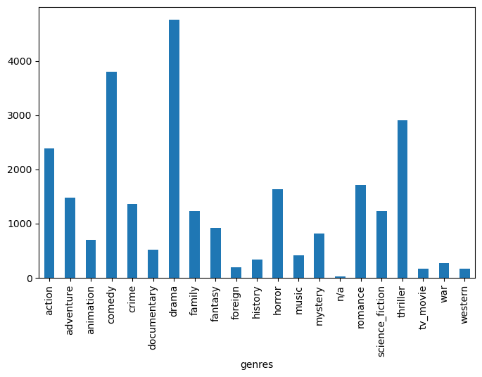

```python
genres.plot(kind='bar', figsize=(8,5));
```

*Now let's select the unique genres from the exploded dataframe `genres` column*

```python
unique_genres = list(genres_exploded.genres.unique())

# Let's see them
unique_genres
```

```
['action',
 'adventure',
 'science_fiction',
 'thriller',
 'fantasy',
 'crime',
 'western',
 'drama',
 'family',
 'animation',
 'comedy',
 'mystery',
 'romance',
 'war',
 'history',
 'music',
 'horror',
 'documentary',
 'tv_movie',
 'n/a',
 'foreign']
```

```python
# How many unique genres do we have

len(unique_genres)
```

```
21
```

```python
# we can add each unique genre as a column to the dataset

movies[unique_genres] = pd.DataFrame(columns=unique_genres, index=movies.index).fillna(0)
```

```python
movies.head()
```

|  | id | imdb_id | popularity | budget | revenue | original_title | cast | homepage | director | tagline | keywords | overview | runtime | genres | production_companies | release_date | vote_count | vote_average | release_year | budget_adj | revenue_adj | action | adventure | science_fiction | thriller | fantasy | crime | western | drama | … |
| --- | --- | --- | --- | --- | --- | --- | --- | --- | --- | --- | --- | --- | --- | --- | --- | --- | --- | --- | --- | --- | --- | --- | --- | --- | --- | --- | --- | --- | --- | --- |
| 0 | 135397 | tt0369610 | 32.985763 | 150000000 | 1513528810 | Jurassic World | Chris Pratt\|Bryce Dallas Howard\|Irrfan Khan\|Vi... | http://www.jurassicworld.com/ | Colin Trevorrow | The park is open. | monster\|dna\|tyrannosaurus rex\|velociraptor\|island | Twenty-two years after the events of Jurassic ... | 124 | [action, adventure, science_fiction, thriller] | Universal Studios\|Amblin Entertainment\|Legenda... | 6/9/15 | 5562 | 6.5 | 2015 | 1.379999e+08 | 1.392446e+09 | 0 | 0 | 0 | 0 | 0 | 0 | 0 | 0 | … |
| 1 | 76341 | tt1392190 | 28.419936 | 150000000 | 378436354 | Mad Max: Fury Road | Tom Hardy\|Charlize Theron\|Hugh Keays-Byrne\|Nic... | http://www.madmaxmovie.com/ | George Miller | What a Lovely Day. | future\|chase\|post-apocalyptic\|dystopia\|australia | An apocalyptic story set in the furthest reach... | 120 | [action, adventure, science_fiction, thriller] | Village Roadshow Pictures\|Kennedy Miller Produ... | 5/13/15 | 6185 | 7.1 | 2015 | 1.379999e+08 | 3.481613e+08 | 0 | 0 | 0 | 0 | 0 | 0 | 0 | 0 | … |
| 2 | 262500 | tt2908446 | 13.112507 | 110000000 | 295238201 | Insurgent | Shailene Woodley\|Theo James\|Kate Winslet\|Ansel... | http://www.thedivergentseries.movie/#insurgent | Robert Schwentke | One Choice Can Destroy You | based on novel\|revolution\|dystopia\|sequel\|dyst... | Beatrice Prior must confront her inner demons ... | 119 | [adventure, science_fiction, thriller] | Summit Entertainment\|Mandeville Films\|Red Wago... | 3/18/15 | 2480 | 6.3 | 2015 | 1.012000e+08 | 2.716190e+08 | 0 | 0 | 0 | 0 | 0 | 0 | 0 | 0 | … |
| 3 | 140607 | tt2488496 | 11.173104 | 200000000 | 2068178225 | Star Wars: The Force Awakens | Harrison Ford\|Mark Hamill\|Carrie Fisher\|Adam D... | http://www.starwars.com/films/star-wars-episod... | J.J. Abrams | Every generation has a story. | android\|spaceship\|jedi\|space opera\|3d | Thirty years after defeating the Galactic Empi... | 136 | [action, adventure, science_fiction, fantasy] | Lucasfilm\|Truenorth Productions\|Bad Robot | 12/15/15 | 5292 | 7.5 | 2015 | 1.839999e+08 | 1.902723e+09 | 0 | 0 | 0 | 0 | 0 | 0 | 0 | 0 | … |
| 4 | 168259 | tt2820852 | 9.335014 | 190000000 | 1506249360 | Furious 7 | Vin Diesel\|Paul Walker\|Jason Statham\|Michelle ... | http://www.furious7.com/ | James Wan | Vengeance Hits Home | car race\|speed\|revenge\|suspense\|car | Deckard Shaw seeks revenge against Dominic Tor... | 137 | [action, crime, thriller] | Universal Pictures\|Original Film\|Media Rights ... | 4/1/15 | 2947 | 7.3 | 2015 | 1.747999e+08 | 1.385749e+09 | 0 | 0 | 0 | 0 | 0 | 0 | 0 | 0 | … |

Next let's build a method that iterates through each list in the genres column, Then if a movie exists, the particular column position gets a 1

```python
def update_genres(row):
    """This method updates each row of the movies dataset
    @param row: A Pandas Series of each row of the dataset
                row index is the column names of the movie dataset
    """

    # iterate through each list of genres and update the corresponding column
    for genre in row['genres']:
        row[genre] = 1
    return row
```

```python
# Now apply the method to all rows of the dataset at once

movies = movies.apply(update_genres, axis=1)
```

```python
# see the head()

movies.head()
```

|  | id | imdb_id | popularity | budget | revenue | original_title | cast | homepage | director | tagline | keywords | overview | runtime | genres | production_companies | release_date | vote_count | vote_average | release_year | budget_adj | revenue_adj | action | adventure | science_fiction | thriller | fantasy | crime | western | drama | … |
| --- | --- | --- | --- | --- | --- | --- | --- | --- | --- | --- | --- | --- | --- | --- | --- | --- | --- | --- | --- | --- | --- | --- | --- | --- | --- | --- | --- | --- | --- | --- |
| 0 | 135397 | tt0369610 | 32.985763 | 150000000 | 1513528810 | Jurassic World | Chris Pratt\|Bryce Dallas Howard\|Irrfan Khan\|Vi... | http://www.jurassicworld.com/ | Colin Trevorrow | The park is open. | monster\|dna\|tyrannosaurus rex\|velociraptor\|island | Twenty-two years after the events of Jurassic ... | 124 | [action, adventure, science_fiction, thriller] | Universal Studios\|Amblin Entertainment\|Legenda... | 6/9/15 | 5562 | 6.5 | 2015 | 1.379999e+08 | 1.392446e+09 | 1 | 1 | 1 | 1 | 0 | 0 | 0 | 0 | … |
| 1 | 76341 | tt1392190 | 28.419936 | 150000000 | 378436354 | Mad Max: Fury Road | Tom Hardy\|Charlize Theron\|Hugh Keays-Byrne\|Nic... | http://www.madmaxmovie.com/ | George Miller | What a Lovely Day. | future\|chase\|post-apocalyptic\|dystopia\|australia | An apocalyptic story set in the furthest reach... | 120 | [action, adventure, science_fiction, thriller] | Village Roadshow Pictures\|Kennedy Miller Produ... | 5/13/15 | 6185 | 7.1 | 2015 | 1.379999e+08 | 3.481613e+08 | 1 | 1 | 1 | 1 | 0 | 0 | 0 | 0 | … |
| 2 | 262500 | tt2908446 | 13.112507 | 110000000 | 295238201 | Insurgent | Shailene Woodley\|Theo James\|Kate Winslet\|Ansel... | http://www.thedivergentseries.movie/#insurgent | Robert Schwentke | One Choice Can Destroy You | based on novel\|revolution\|dystopia\|sequel\|dyst... | Beatrice Prior must confront her inner demons ... | 119 | [adventure, science_fiction, thriller] | Summit Entertainment\|Mandeville Films\|Red Wago... | 3/18/15 | 2480 | 6.3 | 2015 | 1.012000e+08 | 2.716190e+08 | 0 | 1 | 1 | 1 | 0 | 0 | 0 | 0 | … |
| 3 | 140607 | tt2488496 | 11.173104 | 200000000 | 2068178225 | Star Wars: The Force Awakens | Harrison Ford\|Mark Hamill\|Carrie Fisher\|Adam D... | http://www.starwars.com/films/star-wars-episod... | J.J. Abrams | Every generation has a story. | android\|spaceship\|jedi\|space opera\|3d | Thirty years after defeating the Galactic Empi... | 136 | [action, adventure, science_fiction, fantasy] | Lucasfilm\|Truenorth Productions\|Bad Robot | 12/15/15 | 5292 | 7.5 | 2015 | 1.839999e+08 | 1.902723e+09 | 1 | 1 | 1 | 0 | 1 | 0 | 0 | 0 | … |
| 4 | 168259 | tt2820852 | 9.335014 | 190000000 | 1506249360 | Furious 7 | Vin Diesel\|Paul Walker\|Jason Statham\|Michelle ... | http://www.furious7.com/ | James Wan | Vengeance Hits Home | car race\|speed\|revenge\|suspense\|car | Deckard Shaw seeks revenge against Dominic Tor... | 137 | [action, crime, thriller] | Universal Pictures\|Original Film\|Media Rights ... | 4/1/15 | 2947 | 7.3 | 2015 | 1.747999e+08 | 1.385749e+09 | 1 | 0 | 0 | 1 | 0 | 1 | 0 | 0 | … |

Now, we can drop the original genres column

```python
movies.drop(columns='genres', inplace=True)
```

```python
movies.head(3)
```

|  | id | imdb_id | popularity | budget | revenue | original_title | cast | homepage | director | tagline | keywords | overview | runtime | production_companies | release_date | vote_count | vote_average | release_year | budget_adj | revenue_adj | action | adventure | science_fiction | thriller | fantasy | crime | western | drama | family | … |
| --- | --- | --- | --- | --- | --- | --- | --- | --- | --- | --- | --- | --- | --- | --- | --- | --- | --- | --- | --- | --- | --- | --- | --- | --- | --- | --- | --- | --- | --- | --- |
| 0 | 135397 | tt0369610 | 32.985763 | 150000000 | 1513528810 | Jurassic World | Chris Pratt\|Bryce Dallas Howard\|Irrfan Khan\|Vi... | http://www.jurassicworld.com/ | Colin Trevorrow | The park is open. | monster\|dna\|tyrannosaurus rex\|velociraptor\|island | Twenty-two years after the events of Jurassic ... | 124 | Universal Studios\|Amblin Entertainment\|Legenda... | 6/9/15 | 5562 | 6.5 | 2015 | 1.379999e+08 | 1.392446e+09 | 1 | 1 | 1 | 1 | 0 | 0 | 0 | 0 | 0 | … |
| 1 | 76341 | tt1392190 | 28.419936 | 150000000 | 378436354 | Mad Max: Fury Road | Tom Hardy\|Charlize Theron\|Hugh Keays-Byrne\|Nic... | http://www.madmaxmovie.com/ | George Miller | What a Lovely Day. | future\|chase\|post-apocalyptic\|dystopia\|australia | An apocalyptic story set in the furthest reach... | 120 | Village Roadshow Pictures\|Kennedy Miller Produ... | 5/13/15 | 6185 | 7.1 | 2015 | 1.379999e+08 | 3.481613e+08 | 1 | 1 | 1 | 1 | 0 | 0 | 0 | 0 | 0 | … |
| 2 | 262500 | tt2908446 | 13.112507 | 110000000 | 295238201 | Insurgent | Shailene Woodley\|Theo James\|Kate Winslet\|Ansel... | http://www.thedivergentseries.movie/#insurgent | Robert Schwentke | One Choice Can Destroy You | based on novel\|revolution\|dystopia\|sequel\|dyst... | Beatrice Prior must confront her inner demons ... | 119 | Summit Entertainment\|Mandeville Films\|Red Wago... | 3/18/15 | 2480 | 6.3 | 2015 | 1.012000e+08 | 2.716190e+08 | 0 | 1 | 1 | 1 | 0 | 0 | 0 | 0 | 0 | … |

```python
# !jupyter nbconvert --execute --to pdf cleaning_and_splitting_movie_genres.ipynb
```